# Visual Fields Analysis

Data analysis and plots

Mathilde Josserand and Bastien Lemaire

Tue Apr 28 23:46:15 2020

## Introduction

Visual Field Analysis is an application which automatically quantify:

- left-right preference in eye-use
- animal activity
- animal location in an arena

To use this application, please refer to *Accurate measuring of left and right eye-use in animals’ behavioural lateralization studies using DeepLabCut*, Protocol part.

This RMarkdown file aims to show some analysis that can be done with Visual Field Analysis output.

During this analysis, we will use *VFA* for Visual Fields Analysis.

Frames are automatically printed in a *figures* folder (no need to create a folder). But if you want to print the pictures with a special format adapted to each figures, create a folder called “Plots” and set *print_pic = TRUE* above.

## Data

We use the following input files:

| Input file | Format | Animal | Description |
| --- | --- | --- | --- |
| `chick1byFrame.csv` | CSV file | Chick 1 | Output from *VFA* program, where frames have not been grouped by seconds |
| `chick1bySecond.csv` | CSV file | Chick 1 | Output from *VFA* program, where frames have been grouped by second |
| `chick1_manualcoding.csv` | CSV file | Chick 1 | Manual coding for chick 1 eye use preference, for both top and bottom stimuli |
| `chick_2_dlc_mc.csv` | CSV file | Chick 2 | Manual coding and preference extracted from *VFA* output for the chick location in the arena |
| `chick_2_dlc_mc.csv` | CSV file | Chick 2 | Output from *VFA* program, where frames have not been grouped by seconds |
| `chick_2_dlc_mc.csv` | CSV file | Chick 2 | Output from *VFA* program, where frames have been grouped by seconds |

Let’s visualize the first 6 rows for each file:

Chick 1, by frame (VFA output):

Table continues below

| id | sex | condition | trial | object | position_object | startingframe |
| --- | --- | --- | --- | --- | --- | --- |
| 1 | female | example | 1 | red | top | 179 |
| 1 | female | example | 1 | red | top | 179 |
| 1 | female | example | 1 | red | top | 179 |
| 1 | female | example | 1 | red | top | 179 |
| 1 | female | example | 1 | red | top | 179 |
| 1 | female | example | 1 | red | top | 179 |

Table continues below

| endingframe | distanceMoved | TOPCLOSE | TOP | CENTER | BOTTOM | BOTTOMCLOSE |
| --- | --- | --- | --- | --- | --- | --- |
| 1078 | 1.669 | 0 | 0 | 0 | 0 | 1 |
| 1078 | 2.846 | 0 | 0 | 0 | 0 | 1 |
| 1078 | 3.224 | 0 | 0 | 0 | 0 | 1 |
| 1078 | 0.318 | 0 | 0 | 0 | 0 | 1 |
| 1078 | 0.674 | 0 | 0 | 0 | 0 | 1 |
| 1078 | 1.146 | 0 | 0 | 0 | 0 | 1 |

Table continues below

| frontalbottom | blindbottom | lateralLeftbottom | lateralRightbottom |
| --- | --- | --- | --- |
| 0 | 0.465 | 0.535 | 0 |
| 0 | 0.509 | 0.491 | 0 |
| 0 | 0.561 | 0.439 | 0 |
| 0 | 0.643 | 0.357 | 0 |
| 0 | 0.699 | 0.301 | 0 |
| 0 | 0.705 | 0.295 | 0 |

Table continues below

| LeftALLbottom | RightALLbottom | frontaltop | blindtop | lateralLefttop |
| --- | --- | --- | --- | --- |
| 0.535 | 0 | 1 | 0 | 0 |
| 0.491 | 0 | 1 | 0 | 0 |
| 0.439 | 0 | 1 | 0 | 0 |
| 0.357 | 0 | 1 | 0 | 0 |
| 0.301 | 0 | 1 | 0 | 0 |
| 0.295 | 0 | 1 | 0 | 0 |

Table continues below

| lateralRighttop | LeftALLtop | RightALLtop | index_nan_no_stim | frames |
| --- | --- | --- | --- | --- |
| 0 | 0.44 | 0.56 | 182 | 1 |
| 0 | 0.575 | 0.425 | 183 | 2 |
| 0 | 0.631 | 0.369 | 184 | 3 |
| 0 | 0.795 | 0.205 | 185 | 4 |
| 0 | 1 | 0 | 186 | 5 |
| 0 | 1 | 0 | 187 | 6 |

| seconds_full | seconds |
| --- | --- |
| 1 | 0.03333 |
| 1 | 0.06667 |
| 1 | 0.1 |
| 1 | 0.1333 |
| 1 | 0.1667 |
| 1 | 0.2 |

Chick 1, by seconds (VFA output):

Table continues below

| seconds | id | sex | condition | trial | object | position_object |
| --- | --- | --- | --- | --- | --- | --- |
| 1 | 1 | female | example | 1 | red | top |
| 2 | 1 | female | example | 1 | red | top |
| 3 | 1 | female | example | 1 | red | top |
| 4 | 1 | female | example | 1 | red | top |
| 5 | 1 | female | example | 1 | red | top |
| 6 | 1 | female | example | 1 | red | top |

Table continues below

| startingframe | endingframe | distanceMoved | TOPCLOSE | TOP | CENTER | BOTTOM |
| --- | --- | --- | --- | --- | --- | --- |
| 179 | 1078 | 52.73 | 0 | 0 | 0 | 1 |
| 179 | 1078 | 24.45 | 0 | 0 | 0 | 1 |
| 179 | 1078 | 26.42 | 0 | 0 | 0 | 1 |
| 179 | 1078 | 51.17 | 0 | 0 | 0 | 1 |
| 179 | 1078 | 30.63 | 0 | 0 | 0 | 1 |
| 179 | 1078 | 59.2 | 0 | 0 | 0 | 1 |

Table continues below

| BOTTOMCLOSE | frontalbottom | blindbottom | lateralLeftbottom |
| --- | --- | --- | --- |
| 0 | 0 | 0.855 | 0.145 |
| 0 | 0 | 1 | 0 |
| 0 | 0 | 0.944 | 0.056 |
| 0 | 0 | 0.72 | 0.28 |
| 0 | 0 | 0.692 | 0.308 |
| 0 | 0 | 0.766 | 0.234 |

Table continues below

| lateralRightbottom | LeftALLbottom | RightALLbottom | frontaltop | blindtop |
| --- | --- | --- | --- | --- |
| 0 | 0.145 | 0 | 0.997 | 0 |
| 0 | 0 | 0 | 1 | 0 |
| 0 | 0.056 | 0 | 1 | 0 |
| 0 | 0.28 | 0 | 0.923 | 0 |
| 0 | 0.308 | 0 | 0.936 | 0 |
| 0 | 0.234 | 0 | 0.395 | 0 |

Table continues below

| lateralLefttop | lateralRighttop | LeftALLtop | RightALLtop |
| --- | --- | --- | --- |
| 0.003 | 0 | 0.914 | 0.086 |
| 0 | 0 | 0.895 | 0.105 |
| 0 | 0 | 0.412 | 0.588 |
| 0 | 0.077 | 0.01 | 0.99 |
| 0 | 0.064 | 0 | 1 |
| 0 | 0.605 | 0 | 1 |

| index_nan_no_stim | nan | nan_nostim |
| --- | --- | --- |
| 5655 | 0 | 0 |
| 6496 | 0 | 0 |
| 7337 | 0 | 0 |
| 8178 | 0 | 0 |
| 9019 | 0 | 0 |
| 9860 | 0 | 0 |

Chick 1, manual coding:

Table continues below

| seconds | frontalbottom | blindbottom | lateralLeftbottom | lateralRightbottom |
| --- | --- | --- | --- | --- |
| 1 | 0 | 0.6 | 0.4 | 0 |
| 2 | 0 | 0.55 | 0.45 | 0 |
| 3 | 0 | 0.5 | 0.5 | 0 |
| 4 | 0 | 0.4 | 0.6 | 0 |
| 5 | 0 | 0.4 | 0.6 | 0 |
| 6 | 0 | 0.2 | 0.8 | 0 |

Table continues below

| LeftALLbottom | RightALLbottom | frontaltop | blindtop | lateralLefttop |
| --- | --- | --- | --- | --- |
| 0.4 | 0 | 1 | 0 | 0 |
| 0.45 | 0 | 1 | 0 | 0 |
| 0.5 | 0 | 1 | 0 | 0 |
| 0.6 | 0 | 0.85 | 0 | 0 |
| 0.6 | 0 | 0.85 | 0 | 0 |
| 0.8 | 0 | 0.1 | 0 | 0 |

| lateralRighttop | LeftALLtop | RightALLtop |
| --- | --- | --- |
| 0 | 1 | 0 |
| 0 | 0.8 | 0.2 |
| 0 | 0.7 | 0.3 |
| 0.15 | 0 | 1 |
| 0.15 | 0 | 1 |
| 0.9 | 0 | 1 |

Chick 2, both manual coding and DLC:

|  | LEFTCLOSE | LEFT | CENTER | RIGHT | RIGHTCLOSE |
| --- | --- | --- | --- | --- | --- |
| **dlc** | 0.454 | 0.4738 | 0.07219 | 0 | 0 |
| **manual_coding** | 0.4548 | 0.4356 | 0.1096 | 0 | 0 |

## Laterality Index

Before computing the laterality index, let’s have a look to the mean of our columns of interests:

Table continues below

|  | frontaltop | lateralLefttop | lateralRighttop |
| --- | --- | --- | --- |
| **Automatic frames** | 21.1 | 9.3 | 69.61 |
| **Automatic seconds** | 21.16 | 9.35 | 69.48 |
| **Manual coding** | 20.65 | 12.9 | 66.45 |

|  | LeftALLtop | RightALLtop |
| --- | --- | --- |
| **Automatic frames** | 19.54 | 80.46 |
| **Automatic seconds** | 19.65 | 80.35 |
| **Manual coding** | 24.19 | 75.81 |

### Computation

*Laterality Index* is computed with the following formula:

$\displaystyle \frac {number\;of\;frames\;spent\;looking\;with\;the\;right\;visual\;field}{number\;of\;frames\;spent\;looking with\;the\;left\;and\;right\;visual\;field}$

A LI index higher than 50 indicates a preference for using the right visual field, whereas a LI index inferior to 50 indicates a preference for the use of the left visual field.

Please note that we did not replace NA values, but we performed the mean with missing values.

**For overall view (both lateral + frontal):**

When considering the **overall** view, the laterality index is 80.46 % for the automatic coding by frames, 80.35 % for the automatic coding by seconds, and 75.81 % for the manual coding.

**For lateral view only**

When considering the **lateral** view, the laterality index is 87.65 % for the automatic coding by frames, 82.76 % for the automatic coding by seconds, and 85.19 % for the manual coding.

**For frontal view only**

Frontal view is not directly available in our files. We will compute it by substracting the *Overall* with the *Lateral*.

When considering the **frontal** view, the laterality index is 53.84 % for the automatic coding by frames, 54.67 % for the automatic coding by seconds, and 70.83 % for the manual coding.

Let’s gather those results into a single dataframe:

|  | LI_overall | LI_lateral | LI_frontal |
| --- | --- | --- | --- |
| **Automatic frames** | 80.46 | 87.65 | 53.84 |
| **Automatic seconds** | 80.35 | 82.76 | 54.67 |
| **Manual coding** | 75.81 | 85.19 | 70.83 |

### Data format change

We changed data format to obtain 3 different dataframes for each file:

*VFA output, by frames:*

| seconds | condition | LI | coding_type |
| --- | --- | --- | --- |
| Min. : 0.03333 | overall:898 | Min. : 0.00 | automatic_frame:2694 |
| 1st Qu.: 7.50000 | lateral:898 | 1st Qu.:100.00 | NA |
| Median :14.98333 | frontal:898 | Median :100.00 | NA |
| Mean :14.98333 | NA | Mean : 80.38 | NA |
| 3rd Qu.:22.46667 | NA | 3rd Qu.:100.00 | NA |
| Max. :29.93333 | NA | Max. :100.00 | NA |
| NA | NA | NA’s :834 | NA |

*VFA output, by seconds:*

| seconds | condition | LI | coding_type |
| --- | --- | --- | --- |
| Min. : 1 | overall:31 | Min. : 0.00 | automatic_seconds:93 |
| 1st Qu.: 8 | lateral:31 | 1st Qu.: 98.92 | NA |
| Median :16 | frontal:31 | Median :100.00 | NA |
| Mean :16 | NA | Mean : 78.01 | NA |
| 3rd Qu.:24 | NA | 3rd Qu.:100.00 | NA |
| Max. :31 | NA | Max. :100.00 | NA |
| NA | NA | NA’s :24 | NA |

*Manual coding*

| seconds | condition | LI | coding_type |
| --- | --- | --- | --- |
| Min. : 1 | overall:31 | Min. : 0.00 | manual:93 |
| 1st Qu.: 8 | lateral:31 | 1st Qu.:100.00 | NA |
| Median :16 | frontal:31 | Median :100.00 | NA |
| Mean :16 | NA | Mean : 78.57 | NA |
| 3rd Qu.:24 | NA | 3rd Qu.:100.00 | NA |
| Max. :31 | NA | Max. :100.00 | NA |
| NA | NA | NA’s :23 | NA |

### Plots

#### VFA - frames

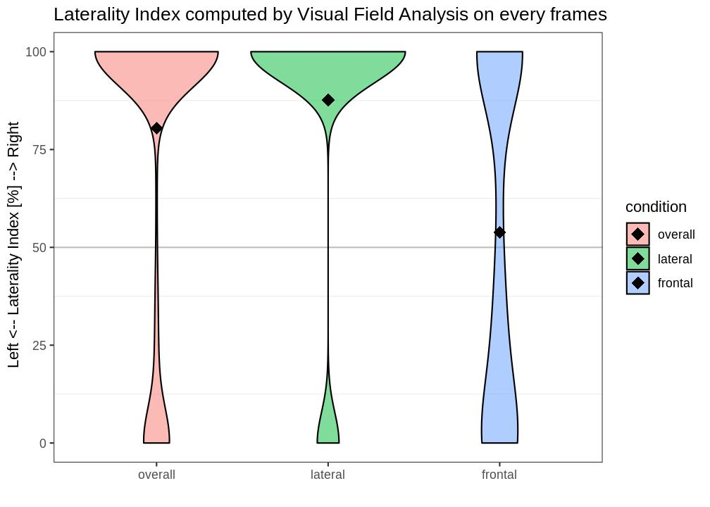

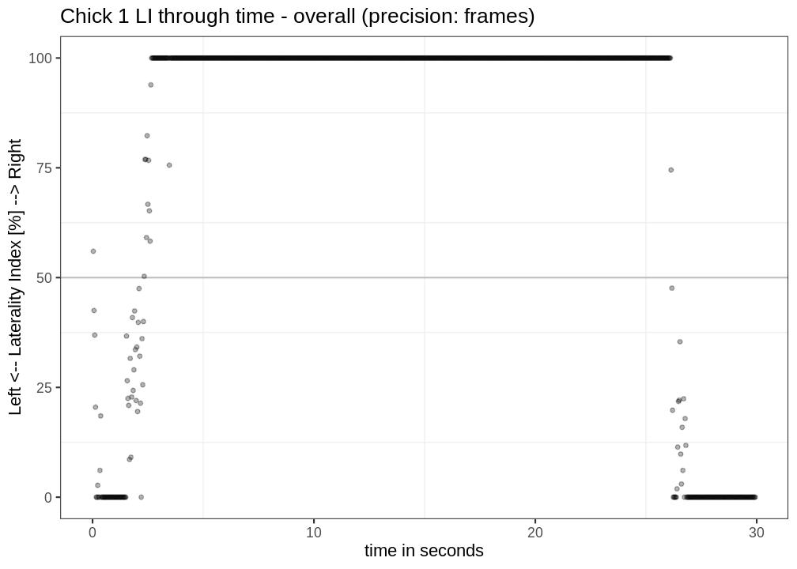

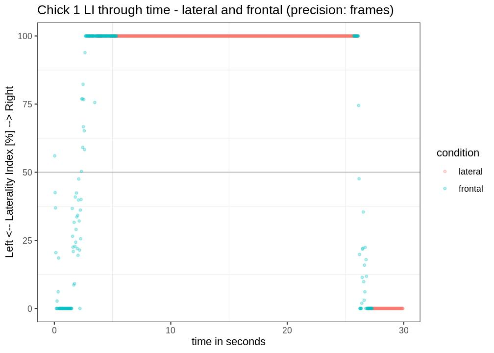

#### VFA - seconds

Here, we do a *very* small change in the data: we replace value above 99 by 100. The change is tiny, but it makes the plot look way better.

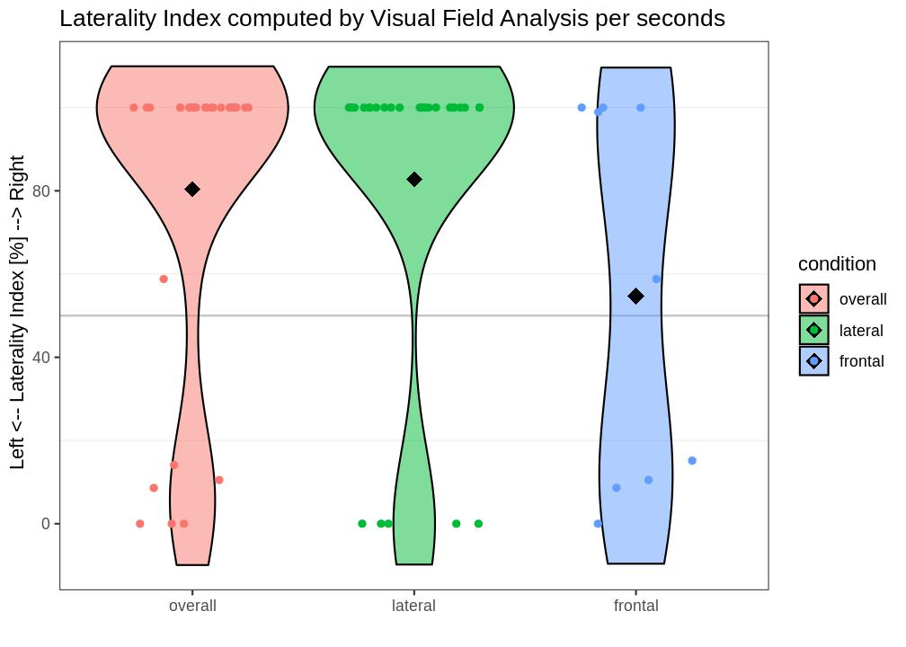

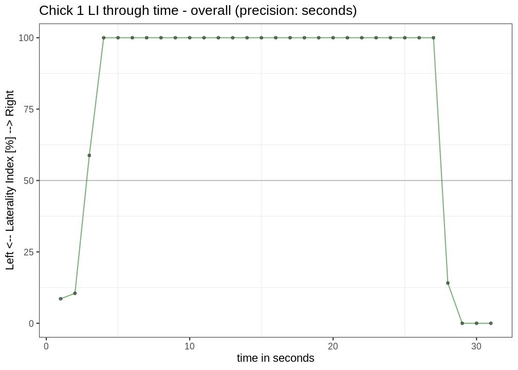

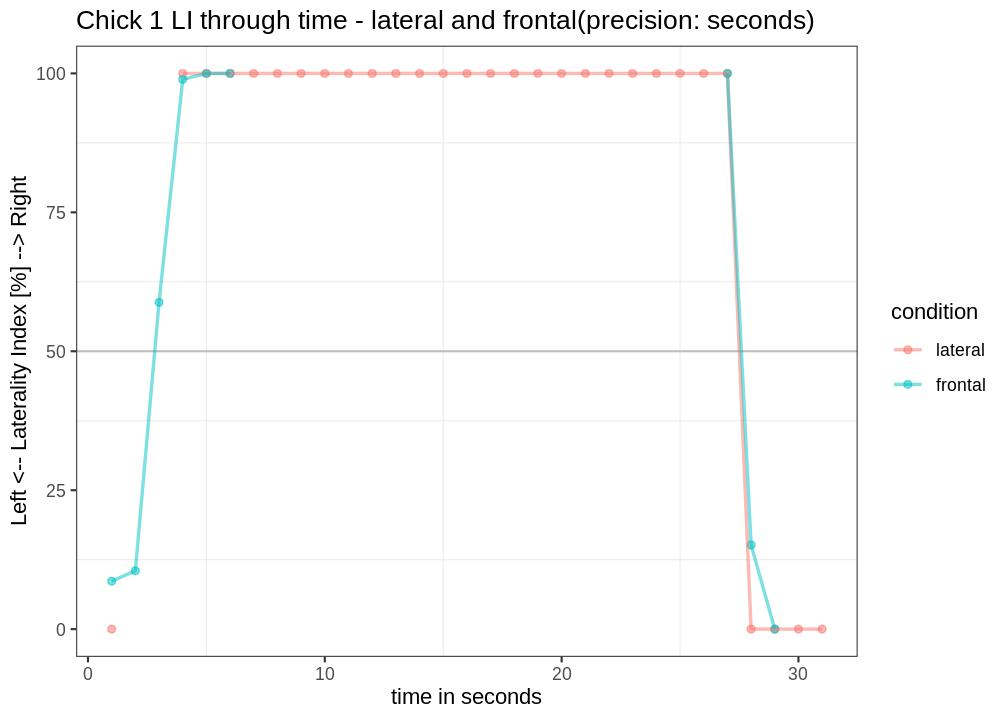

#### Manual coding

Without datapoints inside: (`jitter` function)

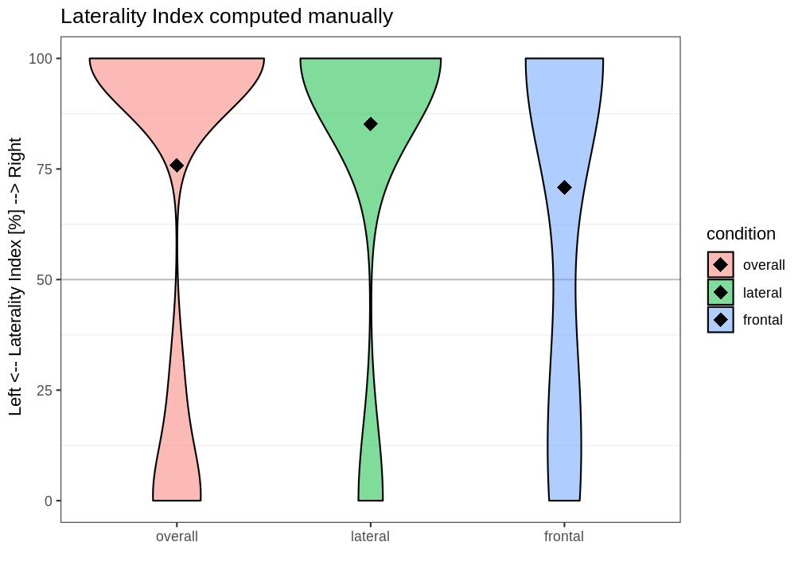

With datapoints inside: (`jitter` function)

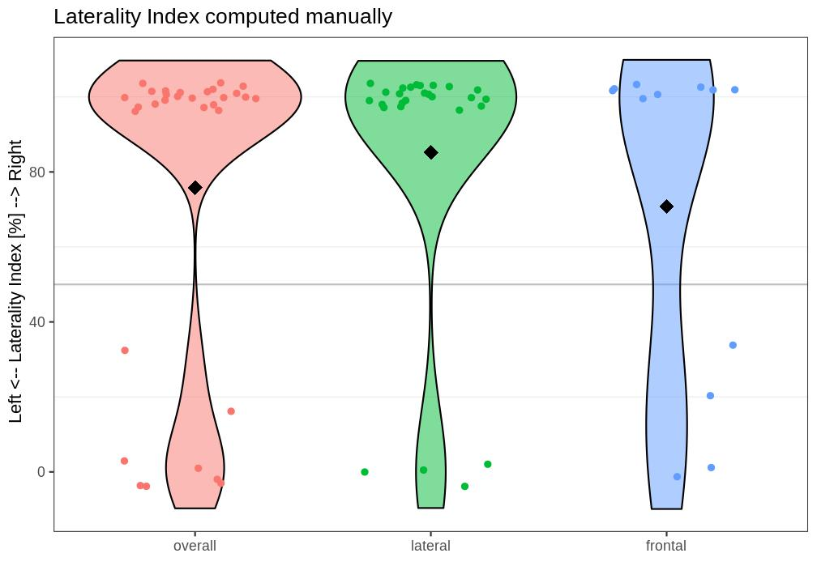

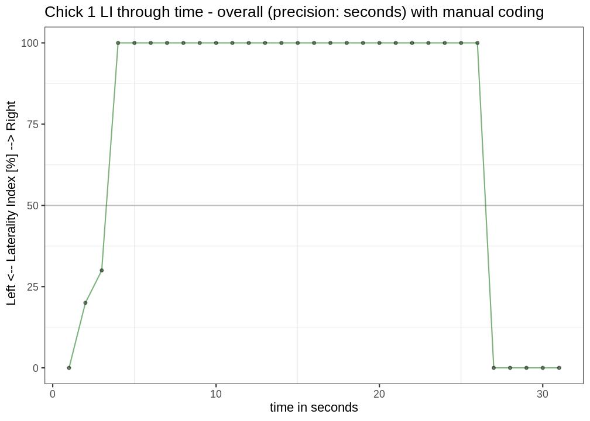

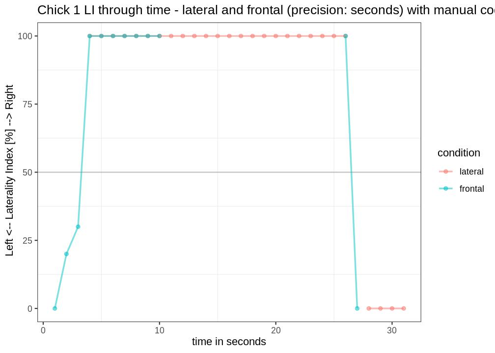

#### All together

In order to plot all these information together, we gather the previous dataframes into one single dataframe:

| seconds | condition | LI | coding_type |
| --- | --- | --- | --- |
| Min. : 0.03333 | overall:960 | Min. : 0.00 | automatic_frame :2694 |
| 1st Qu.: 7.55833 | lateral:960 | 1st Qu.:100.00 | automatic_seconds: 93 |
| Median :15.01667 | frontal:960 | Median :100.00 | manual : 93 |
| Mean :15.04899 | NA | Mean : 80.24 | NA |
| 3rd Qu.:22.54167 | NA | 3rd Qu.:100.00 | NA |
| Max. :31.00000 | NA | Max. :100.00 | NA |
| NA | NA | NA’s :881 | NA |

*Manual coding versus VFA seconds output versus VFA frames output*:

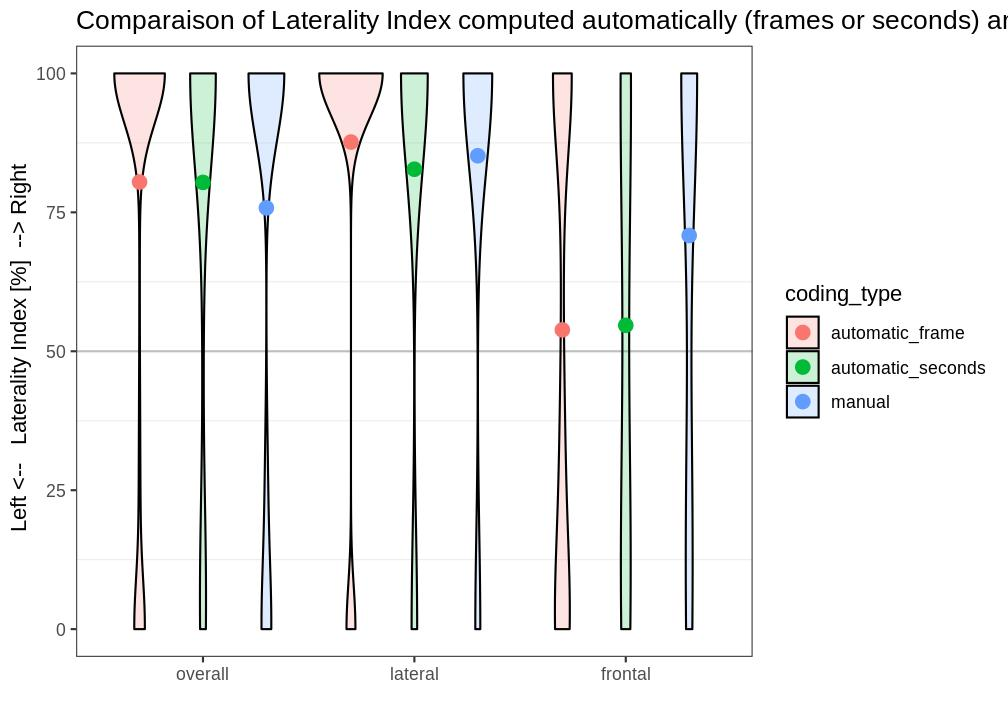

*Manual coding versus VFA seconds output*:

Without datapoints inside: (`jitter` function)

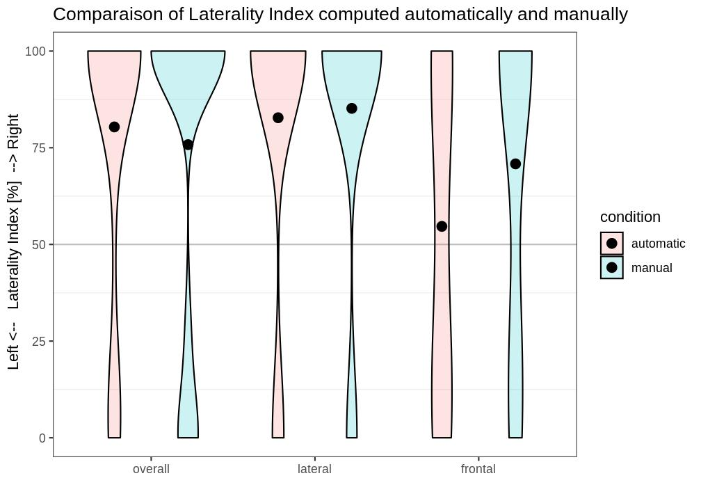

With datapoints inside: (`jitter` function)

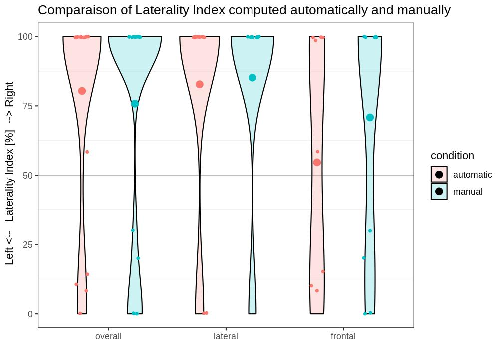

*Manual coding versus VFA frames output*:

Without datapoints inside: (`jitter` function)

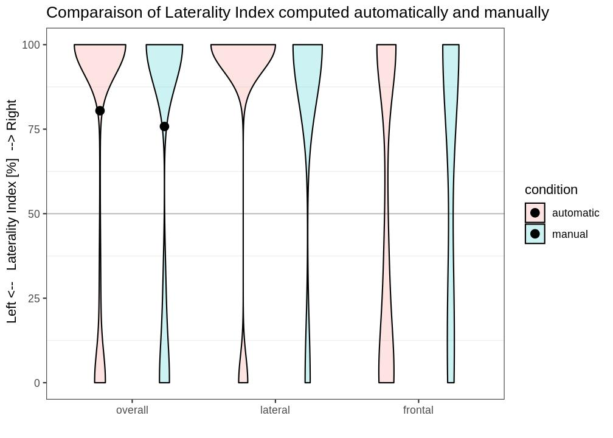

With datapoints inside: (`jitter` function)

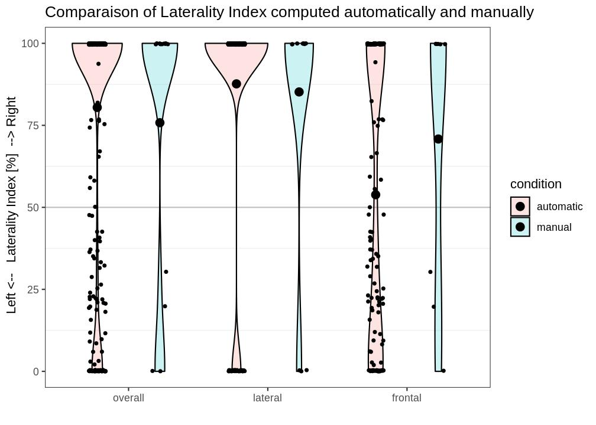

#### Error rate

By error rate, we mean the absolute difference between manual coding and VFA output.

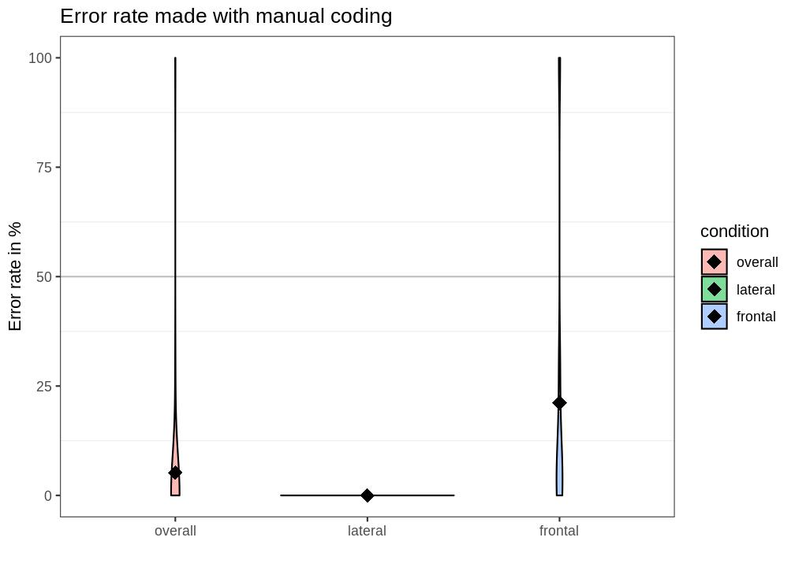

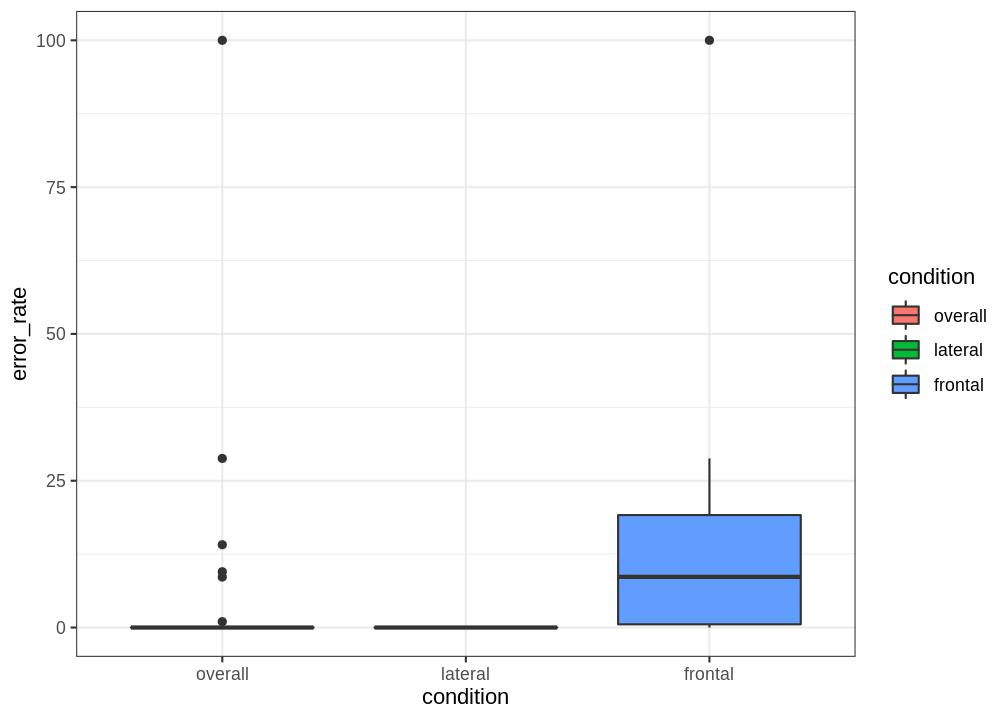

### Differences between manual and automatic coding

Are manual and automatic coding correlated? We use correlations methods such as *Pearson*’s and *Spearman*’s (non parametric) correlation test.

We compare only manual coding versus *VFA* output with seconds to have the same scale.

We gather data in a dataframe where:

- column 1 is the *type* of visual field used: frontal, overall, lateral.
- column 2 is the LI for manual coding
- column 3 is the LI for *VFA* output gathered by seconds

Do our data follow a normal distribution?

```
    Shapiro-Wilk normality test

data:  df_compare$LI_mc
W = 0.5355, p-value = 1.53e-13
```

```
    Shapiro-Wilk normality test

data:  df_compare$LI_aut
W = 0.55556, p-value = 3.905e-13
```

–> our data does **not** follow a normal distribution, so we rely on non-parametric test.

(there are other test to do for other assumptions… As we only want to study correlations, it was not needed here)

We compared the distribution of points for *column 2 and 3*.

*Pearson correlation test for all (overall, frontal, lateral):*

```
    Pearson's product-moment correlation

data:  LI_mc and LI_aut
t = 16.127, df = 63, p-value < 2.2e-16
alternative hypothesis: true correlation is not equal to 0
95 percent confidence interval:
 0.8363433 0.9362429
sample estimates:
      cor
0.8972237
```

*Spearman correlation test (overall, frontal, lateral):*

```
    Spearman's rank correlation rho

data:  LI_mc and LI_aut
S = 6673.4, p-value < 2.2e-16
alternative hypothesis: true rho is not equal to 0
sample estimates:
      rho
0.8541662
```

*Pearson correlation test for overall:*

```
    Pearson's product-moment correlation

data:  LI_mc and LI_aut
t = 10.823, df = 29, p-value = 1.064e-11
alternative hypothesis: true correlation is not equal to 0
95 percent confidence interval:
 0.7923181 0.9486812
sample estimates:
      cor
0.8953021
```

*Spearman correlation test for overall:*

```
    Spearman's rank correlation rho

data:  LI_mc and LI_aut
S = 738.88, p-value = 1.316e-09
alternative hypothesis: true rho is not equal to 0
sample estimates:
      rho
0.8510321
```

*Pearson correlation test for lateral:*

```
    Pearson's product-moment correlation

data:  LI_mc and LI_aut
t = Inf, df = 25, p-value < 2.2e-16
alternative hypothesis: true correlation is not equal to 0
95 percent confidence interval:
 1 1
sample estimates:
cor
  1
```

*Spearman correlation test for lateral:*

```
    Spearman's rank correlation rho

data:  LI_mc and LI_aut
S = 0, p-value < 2.2e-16
alternative hypothesis: true rho is not equal to 0
sample estimates:
rho
  1
```

*Pearson correlation test for frontal:*

```
    Pearson's product-moment correlation

data:  LI_mc and LI_aut
t = 1.9274, df = 5, p-value = 0.1119
alternative hypothesis: true correlation is not equal to 0
95 percent confidence interval:
 -0.1970512  0.9425366
sample estimates:
      cor
0.6528899
```

*Spearman correlation test for frontal:*

```
    Spearman's rank correlation rho

data:  LI_mc and LI_aut
S = 28.814, p-value = 0.2694
alternative hypothesis: true rho is not equal to 0
sample estimates:
      rho
0.4854598
```

–> Our data have a *high* and *positive* correlation: it means that the manual and automatic coding are very similar.

The manual coding for lateral view was perfect, whereas the coding for frontal view is more different.

```
    Welch Two Sample t-test

data:  df_compare$LI_mc and df_compare$LI_aut
t = 0.082369, df = 136.99, p-value = 0.9345
alternative hypothesis: true difference in means is not equal to 0
95 percent confidence interval:
 -12.81766  13.93190
sample estimates:
mean of x mean of y
 78.57143  78.01431
```

```
    Wilcoxon rank sum test with continuity correction

data:  df_compare$LI_mc and df_compare$LI_aut
W = 2490, p-value = 0.6797
alternative hypothesis: true location shift is not equal to 0
```

Our two means are **not** significantly different.

## Lateral/Frontal index

The same way as we computed LI index, we will compute an index which assess the preference for using the frontal or lateral view. We used the following formula:

$\displaystyle \frac {number\;of\;frames\;spent\;looking\;with\;the\;lateral\;visual\;field}{number\;of\;frames\;spent\;looking with\;the\;lateral\;and\;frontal\;visual\;field}$

A LI index higher than 50 indicates a preference for using the lateral visual field, whereas a LI index inferior to 50 indicates a preference for the use of the frontal visual field.

#### Index computation

For *VFA* output by frames, the frontal/lateral index is 78.9 %, which indicate a preference for the lateral visual field.

#### Plots

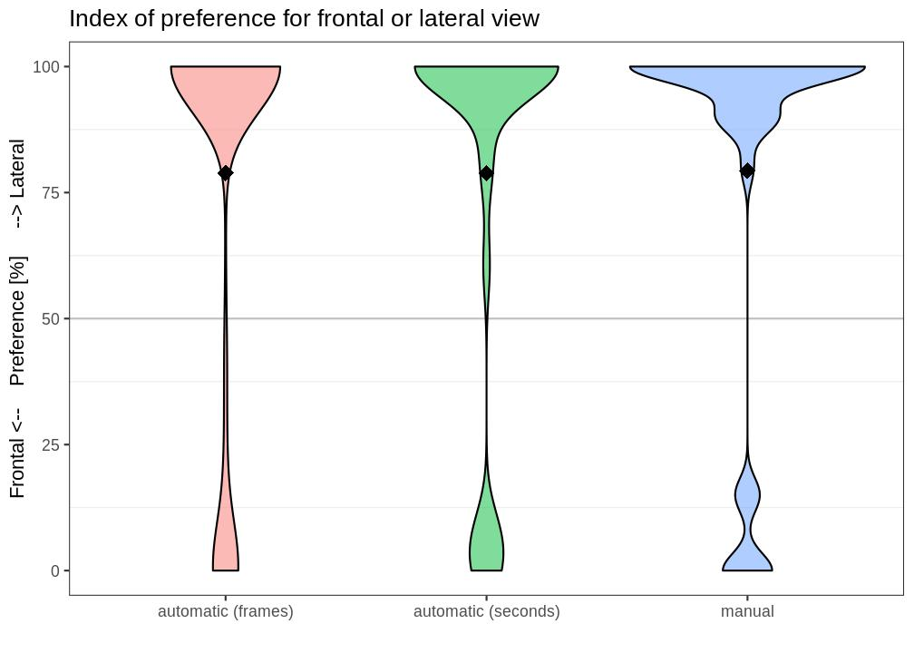

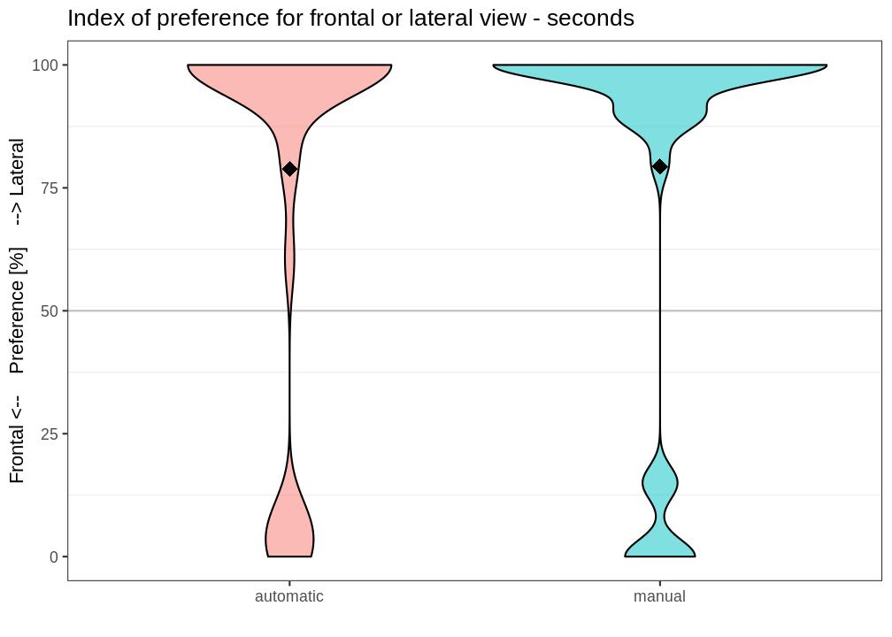

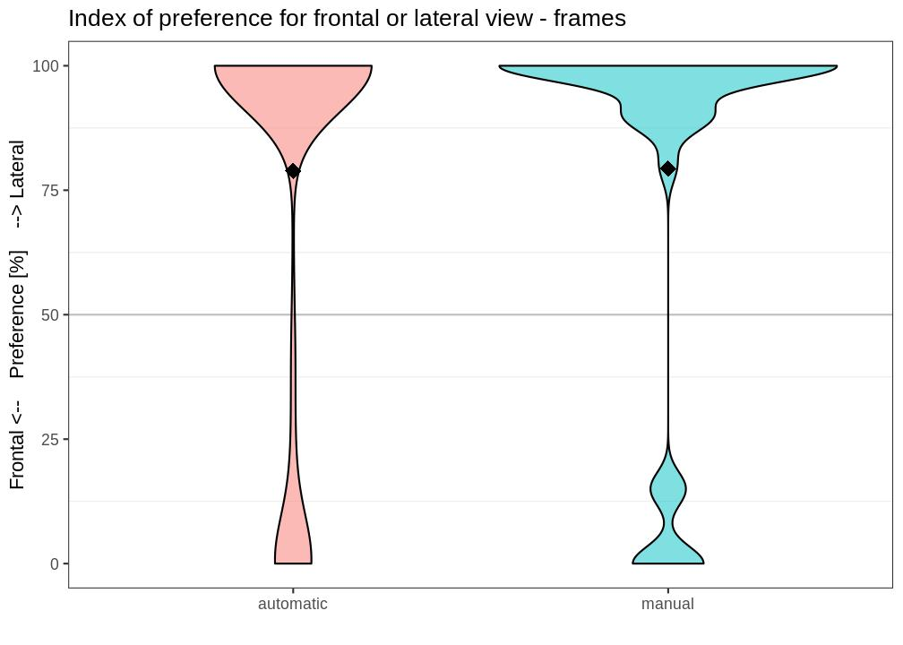

## Movements

#### Chick 1 head movements

##### Precision: frames

With dots:

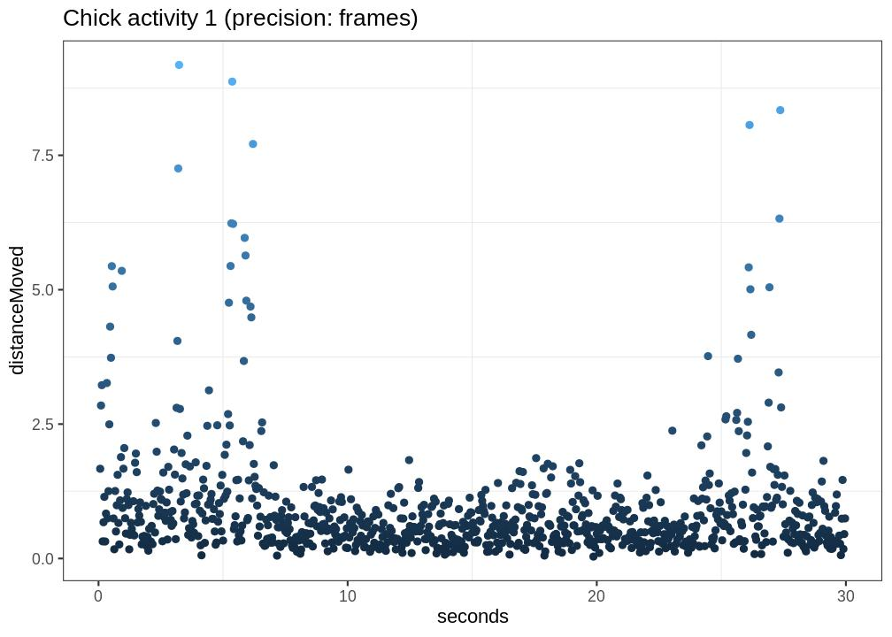

With lines:

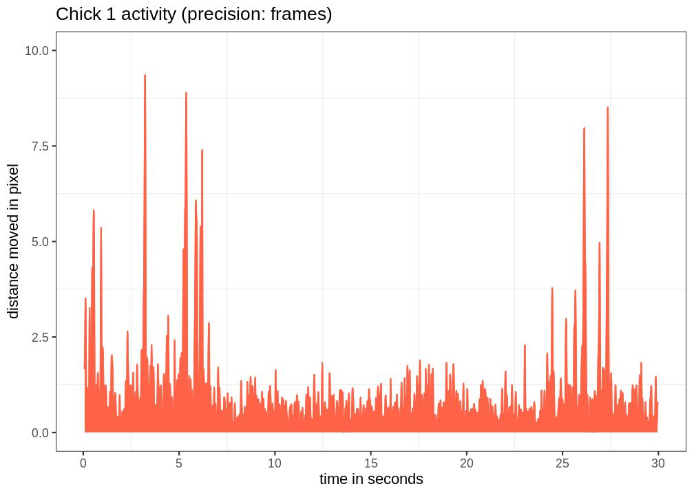

##### Precision: seconds

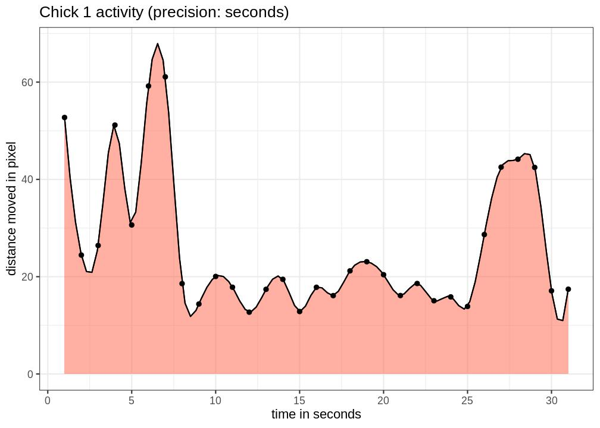

#### Chick 2 head movements

##### Precision: frames

With dots:

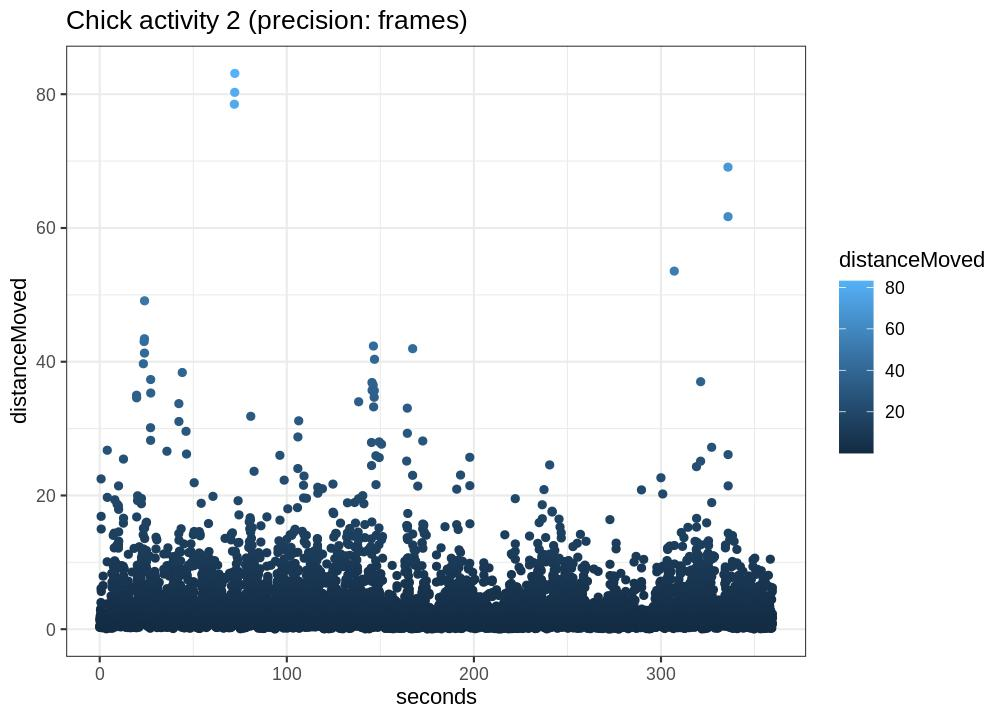

With lines:

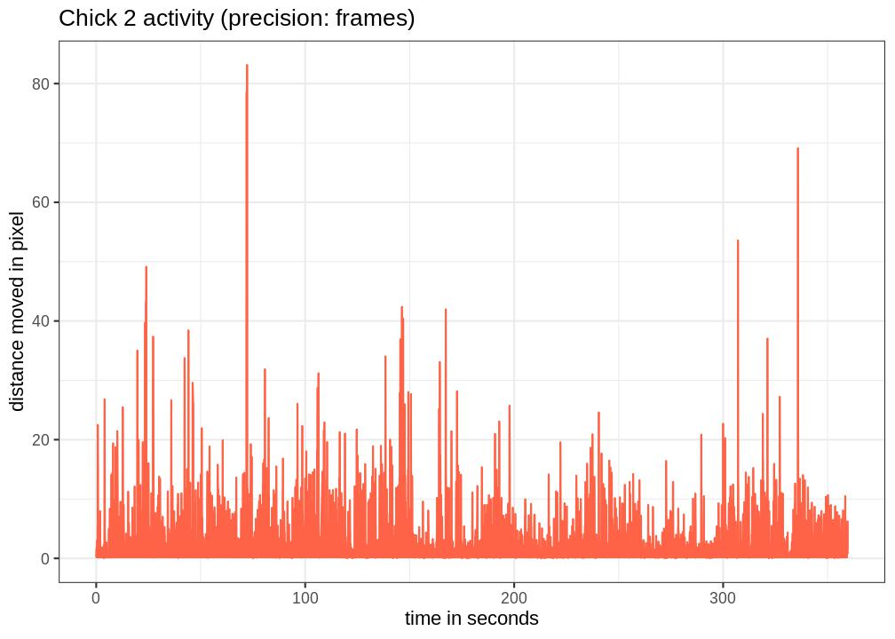

##### Precision: seconds

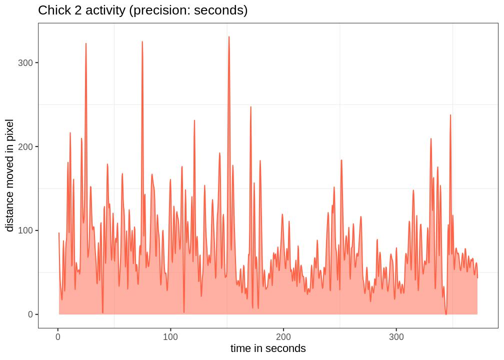

## Location in the arena

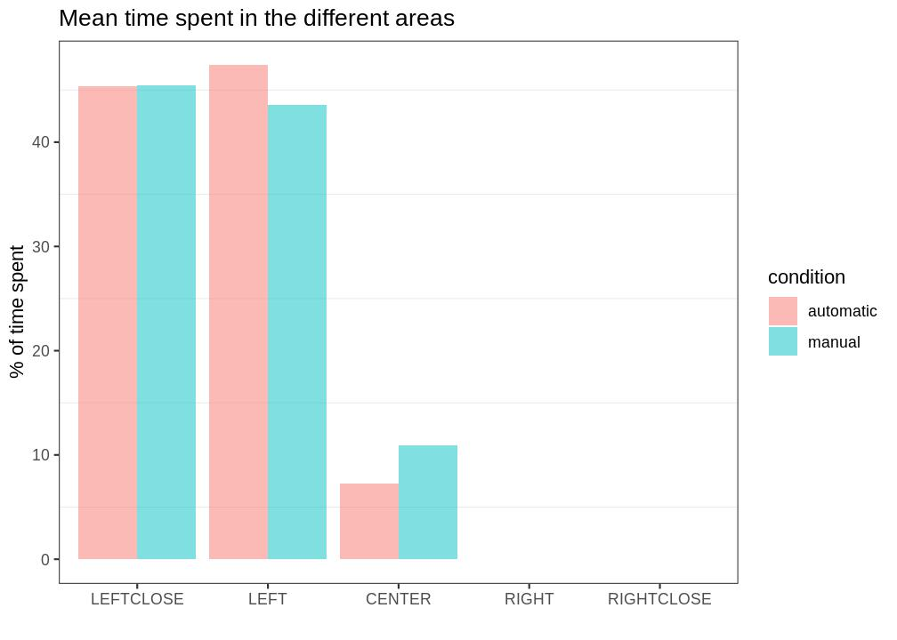

With manual coding, we only coded the total amount of time spent in each areas. The *VFA* output provides additional information concerning the chick: we know at what time it changes its area:

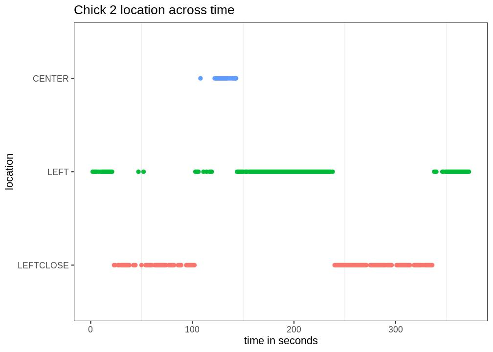